# Chapter 2: BITH Successional Habitat and PCT Treatment Effect

Bayesian Analysis — MBW (2012–2023)

Published

May 17, 2026

# 1 Survey Data Overview

This chapter analyses BITH survey data from the Mountain Birdwatch (MBW) program across New Brunswick clearcut regeneration areas.

- **MBW (Mountain Birdwatch)** — passive unlimited-radius point counts, 2012–2023. Count recorded as the maximum detection within 50 m across all time periods in a survey visit.

Stand age covariates (TSCC: years since clearcut; TSSI: years since PCT) were re-derived for all survey stations by spatially joining station coordinates to 2026 NB Ministry of Supply and Forest stand polygons.

A complementary playback-survey dataset (HELP, 2002–2011, 220 stations, 44 routes) is available but not included in this analysis pending generation of the LiDAR rasters needed to derive focal stand covariates for those stations (see Section 10).

## 1.1 Survey locations

[interactive chart not shown]

MBW survey station locations across New Brunswick (n = 592 stations, 94 routes, 2012–2023). Click a marker for station details.

## 1.2 Detection rates

MBW survey detection rates by treatment track.

| Track | N | N_present | % present | Mean count (nonzero) | Max count |
| --- | --- | --- | --- | --- | --- |
| CC | 1347 | 48 | 3.6 | 1.56 | 4 |
| PCT | 2166 | 227 | 10.5 | 1.50 | 6 |

## 1.3 Stand age at presences

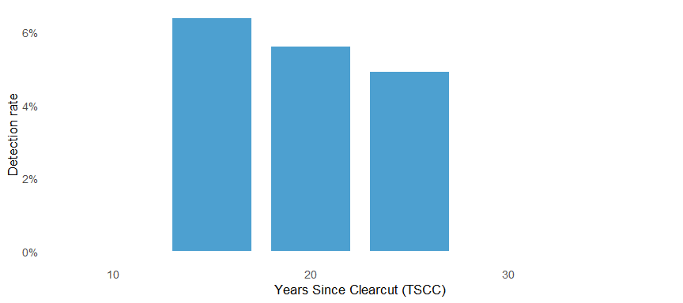

Detection rate (proportion of surveys with ≥1 BITH) by TSCC bin (5-year intervals), CC track.

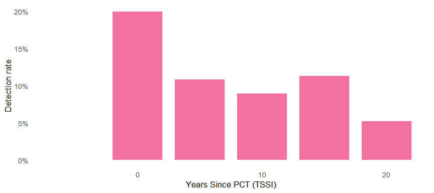

Detection rate (proportion of surveys with ≥1 BITH) by TSSI bin (5-year intervals), PCT track.

## 1.4 Year distribution of presences

MBW detections per year.

| Year | n |
| --- | --- |
| 2012 | 11 |
| 2013 | 9 |
| 2014 | 9 |
| 2015 | 6 |
| 2016 | 20 |
| 2017 | 42 |
| 2018 | 25 |
| 2019 | 32 |
| 2020 | 37 |
| 2021 | 21 |
| 2022 | 32 |
| 2023 | 31 |

# 2 Stand Age Derivation

## 2.1 Derivation method

Stand age covariates were re-derived from the 2026 NB Ministry of Supply and Forest harvest shapefiles (four harvest cohorts: H1 oldest, H4 most recent) rather than relying on field-recorded values in the original survey CSVs.

The spatial join uses `terra::relate("within")` to assign each survey station to the stand polygon it falls inside, with a nearest-polygon fallback for stations within 50 m of a polygon boundary. For MBW, the join key is `(SamplingStation, Stop)` — route codes are shared across stops and a station-only join inflates rows.

The re-derivation script is `rederive_mbw_tscc.R`.

Five MBW routes (15, 18, 25, 35, 75) are present in the survey data but absent from the stand-polygon layer. All 360 visit records from these routes returned no polygon match and consequently have missing `Focal_TRTYR` and `Focal_Dist_Year` values. These stations likely fall on private (non-Crown) land where the NB Ministry harvest shapefiles have no coverage. They are excluded from model fitting via the `!is.na(Focal_TRTYR)` filter.

## 2.2 Focal stand assignment

[interactive chart not shown]

Focal stand assignment for Route 66 (MBW, 2015). Each sampling station is assigned to the stand within 50 m with the highest ISHM-predicted abundance. Coloured polygons are the true scored focal stands from the GeoPackage; station markers share the same colour as their focal stand. Grey polygons are other stands in the vicinity for context. Click a polygon for ISHM score and stand details; hover a station marker for TSCC.

Each station’s focal stand is the stand within 50 m with the highest ISHM-predicted structural abundance. The ISHM integrates canopy height (m), stem density (stems ha⁻¹), elevation, patch adjacency, and riparian proximity — covariates estimated from LiDAR acquired at a single epoch. Because survey years span 2012–2023 but the LiDAR snapshot is fixed, we built a structural chronosequence to allow the two time-varying inputs — canopy height and stem density — to be extrapolated to any survey year. GAMs with Tweedie error ($k = 10$, REML) were fit to both metrics as functions of time since clearcut (TSCC), using all 15,428 scored stands with valid LiDAR measurements and TSCC in [0, 80] years.

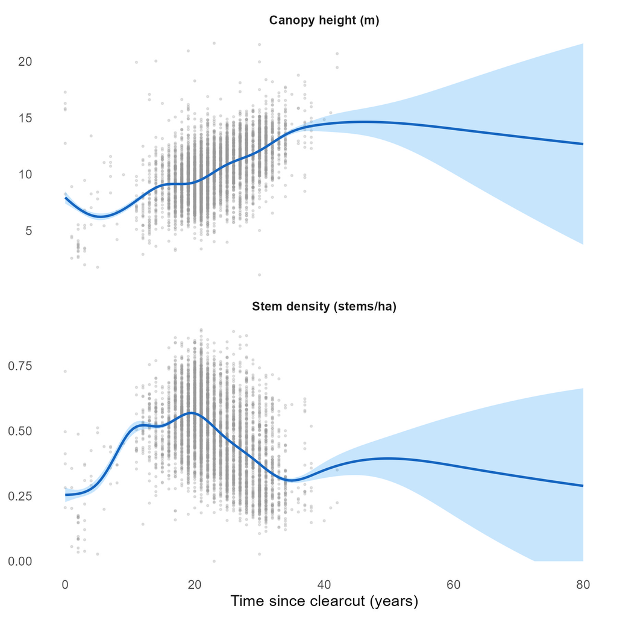

Structural chronosequence of canopy height (top) and stem density (bottom) as functions of time since clearcut (TSCC). Points (grey, 5,000-row sample) are LiDAR measurements from scored stands; blue line is the GAM posterior mean; shaded band is the 95% confidence interval. Both metrics were modelled with Tweedie GAMs (k = 10, REML). For each survey-station × year, the focal stand’s TSCC at that survey year is computed and these GAMs predict the corresponding canopy height and stem density; those values are then fed into the ISHM to obtain a time-varying predicted abundance used for focal stand selection.

At each survey-station × year, the focal stand’s TSCC is computed from the 2026 NB forest inventory and the GAM predictions are fed into the ISHM to obtain a time-varying predicted abundance. Focal stand selection is therefore based on estimated stand quality *at the time of each survey*, rather than a fixed LiDAR-epoch snapshot.

To confirm that ISHM structural scores carry information about actual BITH counts in this network, we fit a Bayesian zero-inflated Poisson validation model predicting observed counts from log(Focal_Predicted_Abundance), with station and route random effects. The posterior mean for the ISHM score coefficient is β = 0.233 (95% CrI: -0.039, 0.546). Although the credible interval grazes zero, the posterior probability that the effect is positive is **P(β > 0) = 0.95** — strong Bayesian evidence that structural stand quality predicts BITH abundance across this monitoring network, even before accounting for successional dynamics.

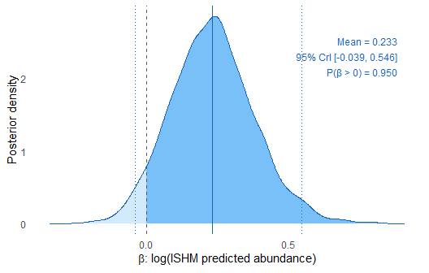

Posterior distribution of the ISHM structural score coefficient (β) from the zero-inflated Poisson validation model. The darker shaded region shows the 95% of posterior mass above zero. Solid vertical line = posterior mean; dotted lines = 95% credible interval; dashed line = zero.

# 3 LiDAR Structural Prior

The structural prior encodes the relationship between stand age and BITH predicted abundance derived from LiDAR-based stand scores across New Brunswick. Models were fit using `brms` with a Gamma(log) family and penalized cyclic splines (`bs = "cs"`). A complexity sweep was run over *k* = 2–10 spline basis functions for each treatment track. The parsimonious winner is the smallest *k* where |ΔELPD| ≤ SE(ΔELPD) — i.e., the simplest model whose LOO score is statistically indistinguishable from the best model (the best model itself satisfies this trivially at ΔELPD = 0).

## 3.1 Complexity sweep and *k* selection

**CC track (TSCC):** winner *k* = 6.

CC track LOO-ELPD by k. Bold = competitive (|ΔELPD| < SE(ΔELPD)); k = 6 selected.

| k | ELPD | ΔELPD | SE(ΔELPD) | Competitive |
| --- | --- | --- | --- | --- |
| 2 | 1925.1 | -34.3 | 13.5 | FALSE |
| 3 | 1925.1 | -34.3 | 13.5 | FALSE |
| 4 | 1922.8 | -36.6 | 13.9 | FALSE |
| 5 | 1943.0 | -16.4 | 10.7 | FALSE |
| 6 | 1956.7 | -2.7 | 6.1 | TRUE |
| 7 | 1950.6 | -8.8 | 8.0 | FALSE |
| 8 | 1958.5 | -0.9 | 1.4 | TRUE |
| 9 | 1955.6 | -3.8 | 2.7 | FALSE |
| 10 | 1959.4 | 0.0 | 0.0 | TRUE |

**PCT track (TSSI):** winner *k* = 8.

PCT track LOO-ELPD by k. Bold = competitive (|ΔELPD| < SE(ΔELPD)); k = 8 selected.

| k | ELPD | ΔELPD | SE(ΔELPD) | Competitive |
| --- | --- | --- | --- | --- |
| 2 | -1565.1 | -69.0 | 30.4 | FALSE |
| 3 | -1565.1 | -69.0 | 30.4 | FALSE |
| 4 | -1534.2 | -38.1 | 21.8 | FALSE |
| 5 | -1541.2 | -45.1 | 23.0 | FALSE |
| 6 | -1507.4 | -11.3 | 11.0 | FALSE |
| 7 | -1520.6 | -24.5 | 15.3 | FALSE |
| 8 | -1497.9 | -1.8 | 4.5 | TRUE |
| 9 | -1497.7 | -1.6 | 7.2 | TRUE |
| 10 | -1496.1 | 0.0 | 0.0 | TRUE |

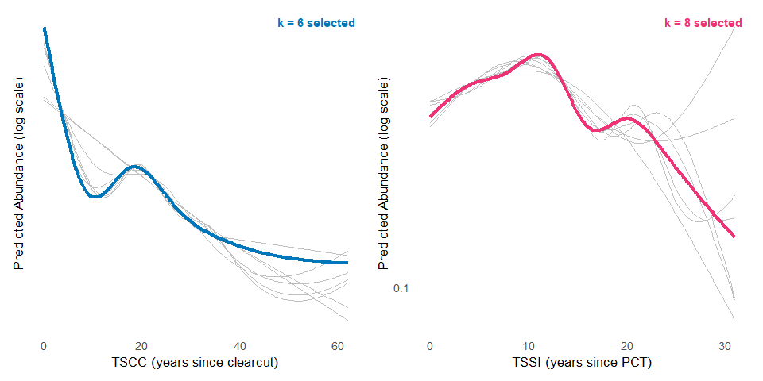

LiDAR prior abundance curves for all candidate spline complexities k = 2–10. Gray lines: non-selected k values (posterior median). Colored line: selected k (CC k = 6 in blue, PCT k = 8 in pink). Selection criterion: smallest k where |ΔELPD| < SE(ΔELPD).

## 3.2 Selected prior parameters

**Prior model winners:** CC track *k* = 6; PCT track *k* = 8 (from `production_run_2026_Balanced`).

These posteriors from the LiDAR-based brms models serve as the structural prior for the joint BITH abundance model. Posterior means become the prior means for the spline coefficients and intercepts; posterior SDs set the prior widths. The prior predictive abundance curves below show the chronosequence implied by the LiDAR structural model alone, before any field survey data are considered.

Intercept prior parameters from the LiDAR structural model.

| Parameter | Prior mean | Prior SD |
| --- | --- | --- |
| Intercept (CC) | -1.114 | 0.008 |
| Intercept (PCT) | -0.775 | 0.009 |

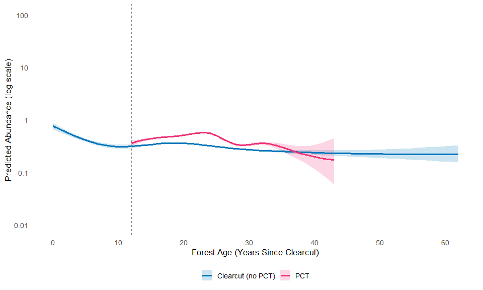

Prior predictive abundance curves from the LiDAR structural models (k = 6 for CC, k = 8 for PCT). Draws taken directly from the brms posterior — no inflation applied. Ribbons show 95% credible interval. Dashed line at TSCC = 12 marks the approximate onset of PCT treatment.

# 4 Model Specification

## 4.1 Likelihood

The model uses a hurdle-Poisson likelihood with protocol-specific parameters. For an observation $y$ with structural predictor $\mu$ and hurdle probability $\theta$:

$$p(y \mid \mu, \theta) =
\begin{cases}
\theta & y = 0 \\
(1 - \theta)\, \dfrac{e^{-\mu}\,\mu^y}{y!\,(1 - e^{-\mu})} & y > 0
\end{cases}$$

The response variable $y$ is the maximum count across up to four 5-minute survey periods. The LiDAR-derived prior, by contrast, is on the $\mathrm{E}[N]$ scale — detection-corrected latent abundance predicted by the ISHM N-mixture model (detection probability $p \approx 0.20$ per period). At that detection rate, $\mathrm{E}[\max(y_1,\ldots,y_4)] \approx 0.5$–$0.6 \times \mathrm{E}[N]$, so fitted model intercepts are on the max-count scale rather than the absolute-abundance scale. This scale offset does not affect the treatment effect ratio: because both CC and PCT tracks share the same survey protocol, $p$ cancels in the ratio $\mu_\text{pct}/\mu_\text{cc}$, leaving the central scientific comparison unaffected.

## 4.2 Linear predictors (two tracks)

Let $\mathbf{x}$ denote the spline basis vector evaluated at the stand age covariate for a given observation:

$$\log \mu = \begin{cases}
\alpha_\text{cc} + \mathbf{x}^\top \boldsymbol{\beta}_\text{cc} & \text{CC} \\
\alpha_\text{pct} + \mathbf{x}^\top \boldsymbol{\beta}_\text{pct} & \text{PCT}
\end{cases}$$

The treatment effect is the ratio of the PCT to no-PCT expected abundance at the same forest age:

$$\frac{\mu_\text{pct}}{\mu_\text{cc}} =
\exp\!\bigl(\alpha_\text{pct} - \alpha_\text{cc}
+ \mathbf{x}^\top(\boldsymbol{\beta}_\text{pct} - \boldsymbol{\beta}_\text{cc})\bigr)$$

## 4.3 Priors

| Parameter | Prior |
| --- | --- |
| $\alpha_\text{cc}$, $\alpha_\text{pct}$ | $\mathcal{N}(\hat\mu_\text{LiDAR},\; f\,\hat\sigma_\text{LiDAR})$ |
| $\boldsymbol{\beta}_\text{cc}$ (K=6) | $\mathcal{N}(\hat{\boldsymbol\mu}_\text{LiDAR},\; f\,\hat{\boldsymbol\sigma}_\text{LiDAR})$ |
| $\boldsymbol{\beta}_\text{pct}$ (K=8) | $\mathcal{N}(\hat{\boldsymbol\mu}_\text{LiDAR},\; f\,\hat{\boldsymbol\sigma}_\text{LiDAR})$ |
| $\theta_\text{mbw}$ | $\text{Beta}(1, 1)$ |

where $f$ is the scale factor controlling how tightly the prior constrains the posterior to the LiDAR estimate (see Section 9.2 for a sensitivity analysis over $f \in \{0.1, 0.2, 0.5, 1, 2, 5, 10\}$; the production model uses $f = 1$).

# 5 Model Fitting

All models were sampled with CmdStanR: 2 chains × 10,000 iterations (5,000 warmup), `adapt_delta = 0.95`.

## 5.1 Code (not evaluated — loads pre-computed)

```r
# -- LiDAR-informed model (LM, FIT_RE_MODELS.R) --
mod <- cmdstan_model("production_run_joint_HELP/joint_HELP_model_re.stan")
fit_LM <- mod$sample(data = stan_data_LM, chains = 2, parallel_chains = 2,
                     iter_warmup = 5000, iter_sampling = 5000, adapt_delta = 0.95)
fit_LM$save_object("production_run_joint_HELP/models/joint_fit_re_LM.rds")

# -- Uninformed model (M, same script) --
fit_M <- mod$sample(data = stan_data_M, chains = 2, parallel_chains = 2,
                    iter_warmup = 5000, iter_sampling = 5000, adapt_delta = 0.95)
fit_M$save_object("production_run_joint_HELP/models/joint_fit_re_M.rds")
```

# 6 Data Source Comparison

We compare three age-based models and one score-based alternative:

- **L** — LiDAR structural prior only; no survey data (baseline)
- **M** — weakly informative prior + MBW surveys
- **LM** — LiDAR structural prior + MBW surveys
- **S** — hurdle-Poisson with ISHM-predicted stand abundance as predictor

**Evaluation strategy:** For observations in a model’s training set (M, LM), we use PSIS-LOO which penalizes for in-sample overfitting. For the prior-only model L, lppd is computed by drawing from the LiDAR structural posterior with Beta(1,1) hurdle probabilities (fully held-out). Models L, M, and LM are all evaluated on the same N = 2162 observations, so their ELPD values are directly comparable. The score model **S** uses a different observation set (N = 2,437 observations with a valid ISHM score within 50 m); spatial leave-one-route-out cross-validation (Section 6.3) provides the fairest comparison between score-based and age-based predictions.

Model comparison. Age-based models evaluated on N = 2162 MBW observations with valid TSCC/TSSI; ΔELPD relative to best age-based model. † Score model (S) evaluated on N = 2,437 observations with valid ISHM score; ELPD not directly comparable — SE(ΔELPD) column shows SE(ELPD) for S. Cor (ρ): Spearman correlation between posterior expected counts and observed counts.

| Model | LiDAR | MBW | ELPD | ΔELPD | SE(ΔELPD) | Cor (ρ) |
| --- | --- | --- | --- | --- | --- | --- |
| M |  | ✓ | -1009.7 | 0 | 0 | 0.032 |
| LM | ✓ | ✓ | -1018.9 | -9.2 | 5.1 | -0.016 |
| L | ✓ |  | -1936.4 | -926.7 | 32.3 | 0.011 |
| S † | score | ✓ | -1011.2 | — | 48.2 | 0.019 |

The best-performing age-based model on LOO-ELPD was **M** (ELPD = -1010). The **LM** model was marginally behind (ΔELPD = -9.2, SE = 5.1), indicating that the LiDAR prior imposes a small but consistent predictive cost relative to the flat prior — the survey data are sufficiently informative that the structural chronosequence adds little incremental LOO performance. The prior-only model (L, ELPD = -1936) performed far worse, confirming that the survey data substantially update the prior. The score-based model (S), which substitutes ISHM-predicted stand abundance for stand age as its predictor, is evaluated on N = 2,437 observations with a valid score; spatial leave-one-route-out cross-validation (Section 6.3) provides the most direct comparison between S and the age-based models.

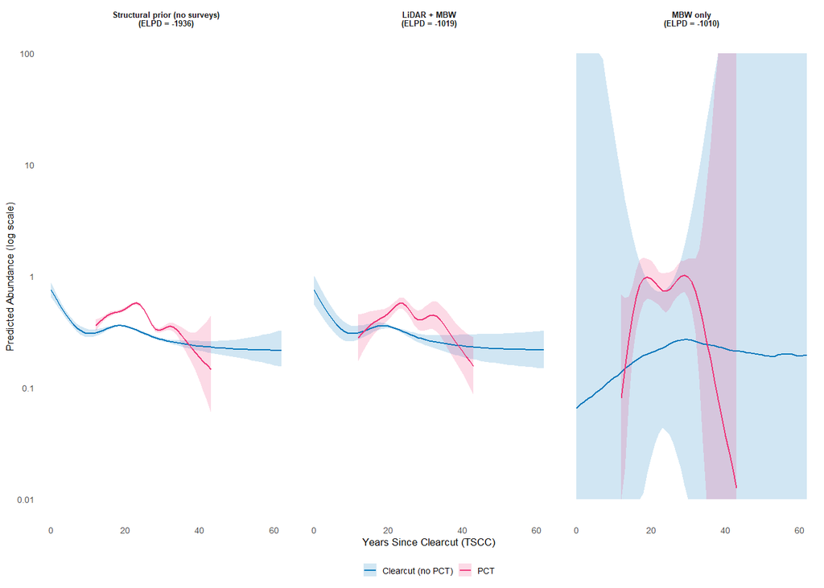

Posterior abundance chronosequences for all three age-based models. Each panel shows the clearcut (blue) and PCT (pink) tracks; PCT is placed on the TSCC axis at TSCC = TSSI + 12. Median posterior shown with 95% credible ribbon. ELPD scores (Table above) reflect out-of-sample predictive performance on the MBW dataset.

## 6.2 M vs LM: where does the LiDAR prior help and hurt?

The LiDAR prior (L) encodes expected abundance from the structural chronosequence alone. When added to the survey model (LM), it pulls the posterior toward the prior curve. The overlay below shows exactly where that pull agrees with the survey data and where it diverges — the direct mechanism behind M outperforming LM on LOO.

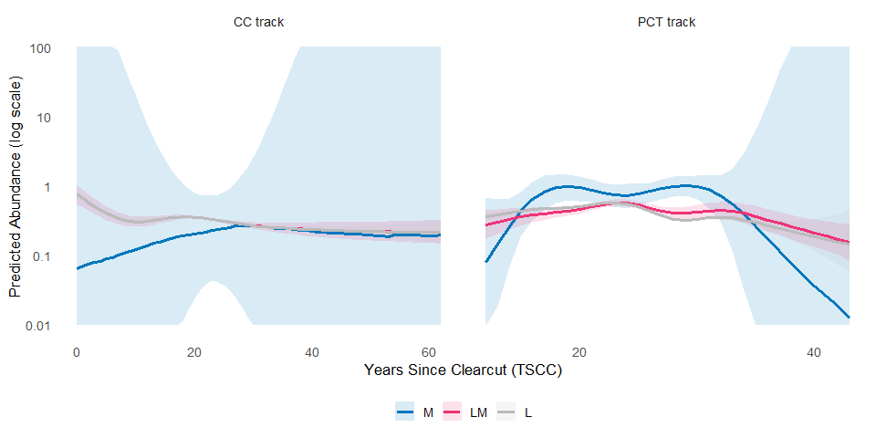

Posterior abundance curves for M (surveys only), LM (surveys + LiDAR prior), and L (LiDAR prior only), split by track. Where LM departs from M, the LiDAR prior is pulling the posterior away from what the surveys estimate. The L curve shows the direction of that pull.

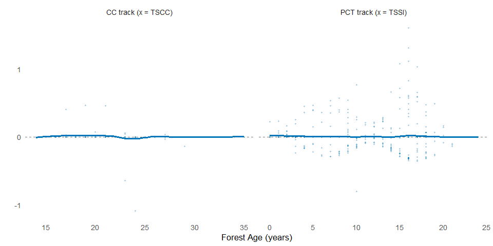

Pointwise ELPD difference (M − LM) per observation, plotted against forest age. Values above zero mean M predicted that observation better; below zero means LM was better. Smoother is LOESS.

## 6.3 Posterior predictive checks and spatial cross-validation

These two diagnostics assess predictive calibration and spatial generalization independently of the ELPD framework.

### Posterior predictive checks (PPC)

Five hundred posterior replications are drawn for each model × dataset combination. Four test statistics are compared between observed data and replicates: proportion of zeros P(Y = 0), mean of non-zero counts, 90th percentile, and maximum count.

Posterior predictive check statistics. ⚠ indicates the observed value falls outside the 90% posterior predictive interval.

| Model | Statistic | Observed | Rep. median | Rep. [5%, 95%] | In interval |
| --- | --- | --- | --- | --- | --- |
| L | 90th pct. | 0.000 | 2.000 | [0.000, 2.000] |  |
| L | Max | 6.000 | 4.000 | [3.000, 5.000] | ⚠ |
| L | Mean (pos.) | 1.477 | 1.232 | [1.202, 1.262] | ⚠ |
| L | P(zero) | 0.901 | 0.486 | [0.051, 0.940] |  |
| LM | 90th pct. | 0.000 | 0.000 | [0.000, 1.000] |  |
| LM | Max | 6.000 | 4.000 | [3.000, 5.000] | ⚠ |
| LM | Mean (pos.) | 1.477 | 1.243 | [1.187, 1.297] | ⚠ |
| LM | P(zero) | 0.901 | 0.901 | [0.886, 0.914] |  |
| M | 90th pct. | 0.000 | 0.000 | [0.000, 1.000] |  |
| M | Max | 6.000 | 5.000 | [4.000, 8.000] |  |
| M | Mean (pos.) | 1.477 | 1.460 | [1.349, 1.607] |  |
| M | P(zero) | 0.901 | 0.901 | [0.886, 0.915] |  |
| S | 90th pct. | 0.000 | 0.000 | [0.000, 1.000] |  |
| S | Max | 6.000 | 4.000 | [4.000, 6.000] |  |
| S | Mean (pos.) | 1.477 | 1.458 | [1.346, 1.571] |  |
| S | P(zero) | 0.901 | 0.902 | [0.886, 0.915] |  |

### Spatial leave-one-route-out cross-validation

For each model, routes are held out one at a time using PSIS importance sampling. The score model (S) and prior-only model (L) are included for direct comparison; S uses grouped LOO like the survey models, while L uses lppd (fully held out). Bars show mean route-level ELPD ± 1 SE.

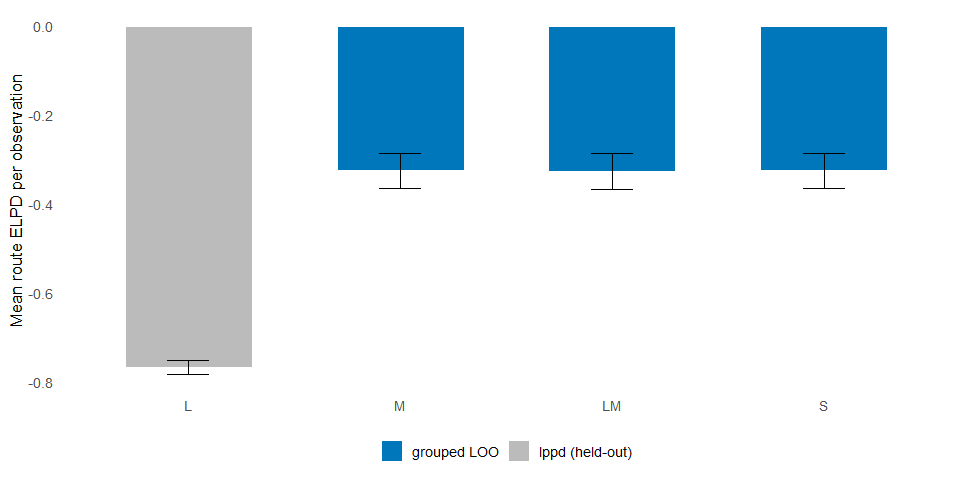

Spatial leave-one-route-out ELPD per observation. Higher is better. Models fitted on that dataset use PSIS grouped LOO; the prior-only model (L) uses lppd. Error bars: ±1 SE across routes.

# 7 Primary Model Diagnostics

## 7.1 Main model diagnostics

Posterior summaries for key parameters (LM model, primary).

| variable | mean | sd | q5 | q95 | rhat | ess_bulk |
| --- | --- | --- | --- | --- | --- | --- |
| Intercept_cc | -1.114 | 0.008 | -1.126 | -1.101 | 1.001 | 22679.19 |
| Intercept_pct | -0.773 | 0.009 | -0.787 | -0.758 | 1.000 | 22529.67 |
| theta_mbw | 0.901 | 0.006 | 0.890 | 0.910 | 1.001 | 27500.22 |
| sigma_station | 0.670 | 0.117 | 0.480 | 0.867 | 1.000 | 5186.70 |

Observation counts: CC-MBW = 0 | PCT-MBW = 2162

## 7.2 Comparison model diagnostics

Posterior summaries for M and LM models.

| Model | variable | mean | sd | rhat | ess_bulk |
| --- | --- | --- | --- | --- | --- |
| M | Intercept_cc | -1.658 | 0.753 | 1.001 | 12659.15 |
| M | Intercept_pct | -0.289 | 0.115 | 1.000 | 14431.30 |
| M | theta_mbw | 0.901 | 0.006 | 1.000 | 22983.59 |
| M | sigma_station | 0.168 | 0.126 | 1.000 | 3956.85 |
| LM | Intercept_cc | -1.114 | 0.008 | 1.001 | 22679.19 |
| LM | Intercept_pct | -0.773 | 0.009 | 1.000 | 22529.67 |
| LM | theta_mbw | 0.901 | 0.006 | 1.001 | 27500.22 |
| LM | sigma_station | 0.670 | 0.117 | 1.000 | 5186.70 |

# 8 Main Results

All results in this section are from the **LM model** (LiDAR structural prior + MBW surveys), loaded from `joint_fit_re_LM.rds`. See Section 6 for the model comparison and Section 9.1 for sensitivity to the prior.

## 8.1 Abundance chronosequence

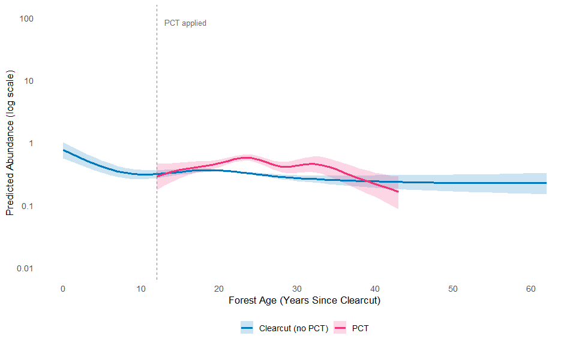

Predicted BITH abundance along the clearcut successional gradient (LM model: LiDAR structural prior + MBW surveys). Blue: clearcut with no PCT treatment. Pink: PCT-treated stand, placed on the TSCC axis at TSCC = TSSI + 12. Dashed line marks approximate PCT application age. Ribbons show 95% credible interval.

Both tracks show broadly declining abundance with increasing forest age, consistent with BITH’s preference for younger successional structure. The CC track is highest in the youngest stands (TSCC < 5 yr), driven partly by the LiDAR prior at the boundary of the data range, and falls to a lower plateau from TSCC ≈ 15–30 before continuing to decline into older forest. The PCT track (plotted on the TSCC axis at TSCC = TSSI + 12) tracks closely with CC in early succession but diverges upward from TSCC ≈ 22–34 (TSSI 10–22), reflecting the structural advantage that thinned stands accumulate over the following decade.

## 8.2 Treatment effect

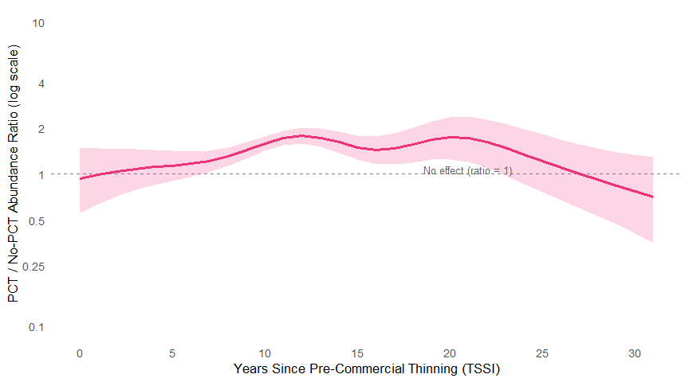

PCT treatment effect expressed as a multiplicative abundance ratio (PCT / no-PCT) from the LM model. Values above 1 indicate positive effect of thinning. Dashed line at ratio = 1 marks no effect. Ribbon shows 95% credible interval.

PCT treatment effect at selected stand ages.

|  | TSSI (yr) | TSCC (yr) | CC abund | PCT abund | Ratio | 95% CI | Evidence |
| --- | --- | --- | --- | --- | --- | --- | --- |
| treatment_effect_mult[1] | 0 | 12 | 0.312 | 0.290 | 0.93 | [0.55, 1.49] | ns |
| treatment_effect_mult[6] | 5 | 17 | 0.356 | 0.406 | 1.14 | [0.91, 1.42] | ns |
| treatment_effect_mult[11] | 10 | 22 | 0.341 | 0.544 | 1.60 | [1.43, 1.78] | pos ** |
| treatment_effect_mult[16] | 15 | 27 | 0.291 | 0.436 | 1.50 | [1.25, 1.80] | pos ** |
| treatment_effect_mult[21] | 20 | 32 | 0.262 | 0.456 | 1.75 | [1.25, 2.37] | pos ** |
| treatment_effect_mult[26] | 25 | 37 | 0.246 | 0.297 | 1.22 | [0.76, 1.83] | ns |
| treatment_effect_mult[31] | 30 | 42 | 0.236 | 0.180 | 0.77 | [0.41, 1.34] | ns |

The PCT treatment effect peaks near TSSI = 12 years (TSCC ≈ 24) with a posterior mean ratio of 1.79 (95% CI [1.58, 2.03]), indicating that thinned stands support approximately 1.79× the BITH abundance of untreated stands at the same forest age.

The effect is not credible immediately after thinning (TSSI 0–5 yr: ratio ≈ 0.93–1.14, CIs crossing 1), consistent with a lag between treatment and structural benefit. It becomes strongly and credibly positive from TSSI ≈ 10 yr onward through TSSI ≈ 20 yr — the window where LM posterior lower bounds are consistently above 1.0 — before widening uncertainty at TSSI ≥ 25 yr causes the credible interval to again straddle no-effect. The post-TSSI-20 decline in estimated effect is real in direction but should be interpreted cautiously: survey data are sparse at older post-PCT ages and the posterior is correspondingly more prior-dependent (see Section 8.2.1).

## 8.2.1 The 12-year post-PCT peak

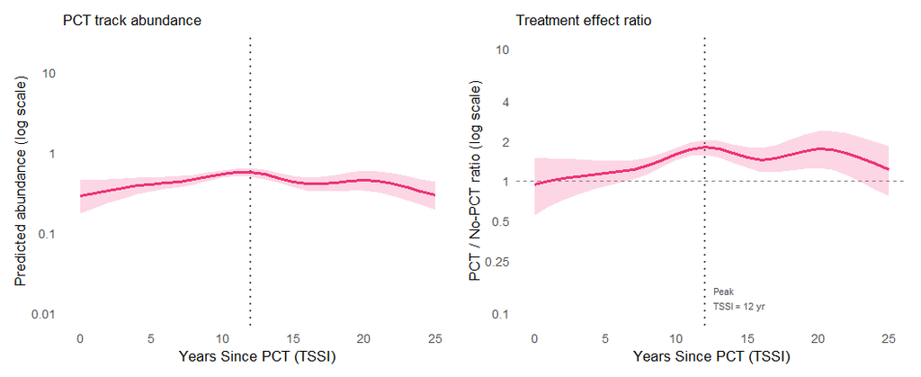

Focused view of the post-PCT chronosequence (TSSI 0–25 years). Left: posterior PCT abundance; right: multiplicative treatment effect (PCT / no-PCT). Both panels share the same TSSI axis. Dotted vertical line marks the posterior peak of the treatment effect. Ribbons show 95% credible intervals.

MBW PCT-track survey coverage by TSSI bin. Detection rate: proportion of surveys with ≥ 1 BITH. Mean count is conditional on detection.

| TSSI (yr) | N | Detections | Det. rate | Mean count &#124; det |
| --- | --- | --- | --- | --- |
| 0–4 | 135 | 27 | 20% | 1.26 |
| 5–9 | 425 | 46 | 11% | 1.48 |
| 10–14 | 806 | 72 | 9% | 1.46 |
| 15–19 | 662 | 75 | 11% | 1.63 |
| 20–24 | 134 | 7 | 5% | 1.57 |

One data-quality note: all TSSI = 0 records (n = 7) have survey year equal to treatment year, so it is unknown whether the survey preceded or followed the thinning. These seven observations are retained but their influence on the posterior is negligible.

The MBW data neither confirm nor contradict this: detection rate is flat at 9–11% across TSSI 5–19, so the surveys do not independently place a peak there. Notably, detection is *highest* at TSSI 0–4 (20%), but the prior suppresses this — recently-thinned stands have reduced stem density and the structural model predicts poor habitat immediately post-treatment. Mean count given detection trends weakly upward with TSSI (1.26 at TSSI 0–4, 1.63 at TSSI 15–19), consistent with higher bird density in better-structured older stands, but the sample sizes are too small to resolve the peak location from surveys alone. The broad credible window (TSSI 10–20) reflects this: the prior shapes the curve, the surveys scale it.

## 8.3 Station-level variation

The model includes flat station-level random intercepts (`alpha_station ~ Normal(0, sigma_station)`) absorbing persistent location-level heterogeneity not explained by forest age or treatment. An initial formulation nested stations within stands (two-level hierarchy), but the stand-level variance component showed severe non-convergence (Rhat = 1.11, ESS = 18; σ<sub>station</sub> Rhat = 1.58, ESS = 4), indicating the data cannot distinguish between-stand from within-stand variance. The flat structure is better identified and produces comparable results (see `models_twolevel_re/` for the archived two-level fits).

Posterior summary for station-level variance component. exp(mean) gives the multiplicative abundance difference associated with a 1-SD shift on the log scale.

| variable | mean | sd | q5 | q95 | rhat | ess_bulk | Multiplicative scale |
| --- | --- | --- | --- | --- | --- | --- | --- |
| sigma_station | 0.67 | 0.117 | 0.48 | 0.867 | 1 | 5186.7 | 1.95 |

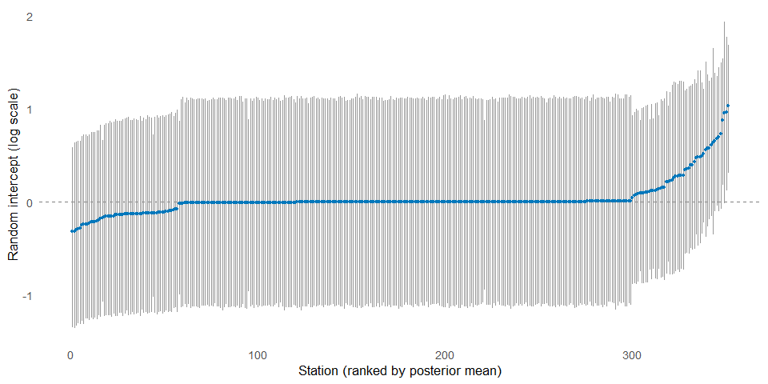

Station-level random intercepts (posterior mean ± 90% CI) sorted by posterior mean. Values on the log scale: a station at +0.5 has ~65% higher expected abundance than average at the same forest age; a station at −0.5 has ~40% lower. Horizontal line at 0 = population mean.

# 9 Prior Sensitivity and Supplementary Models

## 9.1 Model comparison: survey-only (M) vs LiDAR-informed (LM)

These panels compare the posterior abundance curves recovered by M (weakly informative prior + MBW surveys) and LM (LiDAR structural prior + MBW surveys), illustrating where the prior shifts the posterior relative to what the survey data alone support. Point estimates use the posterior median.

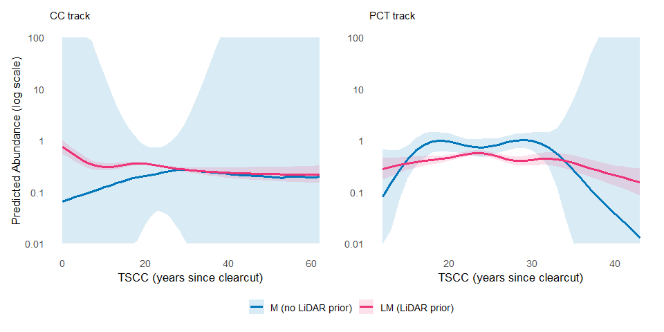

Posterior abundance curves for M (no LiDAR prior) and LM (LiDAR prior). Left: CC track. Right: PCT track. Median posterior shown; ribbons are 95% CI.

## 9.2 Prior scale-factor sensitivity

The LiDAR posterior SDs are multiplied by a scale factor $f$ before being used as prior standard deviations in the Stan model. $f < 1$ tightens the prior (LiDAR shape dominates); $f > 1$ widens it (surveys can move the spline more freely); $f = 1$ is the production LM. At $f \to \infty$ the model approaches M (flat prior). We assess $f \in \{0.1, 0.2, 0.5, 1, 2, 5, 10\}$, spanning “LiDAR ×10” through “Surveys ×10” relative weighting.

LOO-ELPD for LM across prior scale factors. ΔELPD is relative to the loosest prior (Surveys ×10). For reference, the flat-prior M model achieved ELPD = -1009.7.

| scale_factor | label | ELPD | ΔELPD | SE(ΔELPD) |
| --- | --- | --- | --- | --- |
| 10.0 | Surveys ×10 | -1013.1 | 0.0 | 49.0 |
| 5.0 | Surveys ×5 | -1016.1 | -3.0 | 49.3 |
| 2.0 | Surveys ×2 | -1017.9 | -4.8 | 49.4 |
| 1.0 | Balanced | -1018.9 | -5.9 | 49.5 |
| 0.5 | LiDAR ×2 | -1020.9 | -7.9 | 49.7 |
| 0.2 | LiDAR ×5 | -1021.3 | -8.3 | 49.7 |
| 0.1 | LiDAR ×10 | -1021.7 | -8.6 | 49.7 |

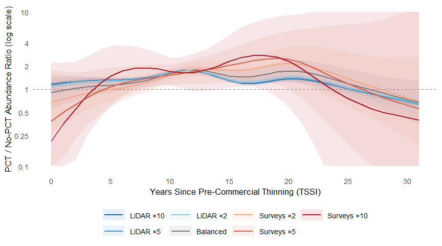

PCT treatment effect (multiplicative ratio) across prior scale factors. Blue curves hold the LiDAR prior tighter; red curves release it toward the surveys. Ribbons show 95% credible intervals.

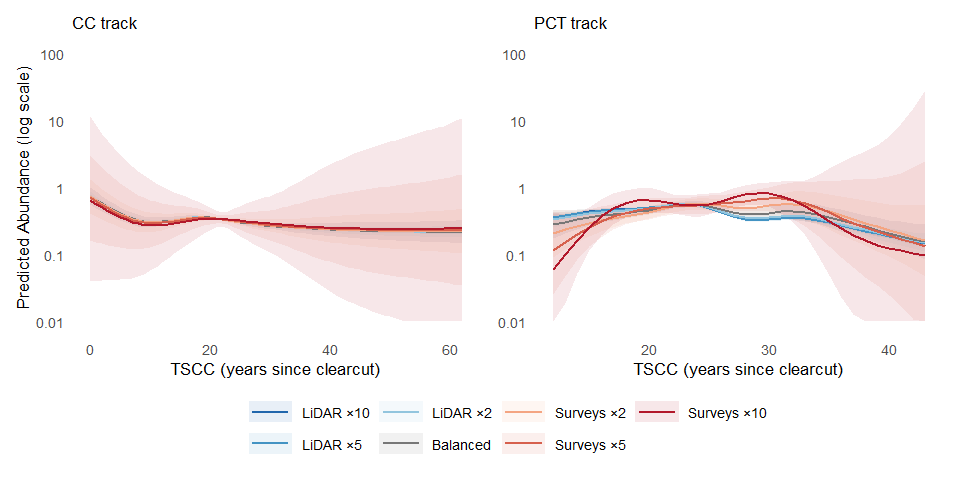

Posterior abundance curves by prior scale factor. Left: clearcut track. Right: PCT track (x-axis = TSCC). Blue = LiDAR-dominated; red = survey-dominated. Ribbons: 95% CI.

Key parameter posteriors across prior scale factors.

| Scale | Parameter | Mean | SD | Q5 | Q95 | R |
| --- | --- | --- | --- | --- | --- | --- |
| LiDAR ×10 | Intercept_cc | -1.114 | 0.001 | -1.115 | -1.112 | 1.000 |
| LiDAR ×5 | Intercept_cc | -1.114 | 0.002 | -1.116 | -1.111 | 1.000 |
| LiDAR ×2 | Intercept_cc | -1.114 | 0.004 | -1.120 | -1.107 | 1.000 |
| Balanced | Intercept_cc | -1.114 | 0.008 | -1.126 | -1.101 | 1.001 |
| Surveys ×2 | Intercept_cc | -1.114 | 0.016 | -1.140 | -1.089 | 1.000 |
| Surveys ×5 | Intercept_cc | -1.117 | 0.039 | -1.181 | -1.052 | 1.001 |
| Surveys ×10 | Intercept_cc | -1.122 | 0.077 | -1.247 | -0.995 | 1.000 |
| LiDAR ×10 | Intercept_pct | -0.775 | 0.001 | -0.776 | -0.773 | 1.000 |
| LiDAR ×5 | Intercept_pct | -0.775 | 0.002 | -0.777 | -0.772 | 1.000 |
| LiDAR ×2 | Intercept_pct | -0.774 | 0.004 | -0.781 | -0.767 | 1.001 |
| Balanced | Intercept_pct | -0.773 | 0.009 | -0.787 | -0.758 | 1.000 |
| Surveys ×2 | Intercept_pct | -0.767 | 0.017 | -0.794 | -0.739 | 1.000 |
| Surveys ×5 | Intercept_pct | -0.729 | 0.043 | -0.799 | -0.658 | 1.001 |
| Surveys ×10 | Intercept_pct | -0.616 | 0.078 | -0.742 | -0.488 | 1.000 |
| LiDAR ×10 | sigma_station | 0.726 | 0.118 | 0.539 | 0.925 | 1.000 |
| LiDAR ×5 | sigma_station | 0.724 | 0.118 | 0.538 | 0.922 | 1.000 |
| LiDAR ×2 | sigma_station | 0.705 | 0.118 | 0.517 | 0.907 | 1.001 |
| Balanced | sigma_station | 0.670 | 0.117 | 0.480 | 0.867 | 1.000 |
| Surveys ×2 | sigma_station | 0.608 | 0.125 | 0.405 | 0.812 | 1.000 |
| Surveys ×5 | sigma_station | 0.516 | 0.142 | 0.276 | 0.740 | 1.001 |
| Surveys ×10 | sigma_station | 0.359 | 0.168 | 0.058 | 0.624 | 1.000 |
| LiDAR ×10 | theta_mbw | 0.901 | 0.006 | 0.891 | 0.910 | 1.000 |
| LiDAR ×5 | theta_mbw | 0.901 | 0.006 | 0.890 | 0.910 | 1.000 |
| LiDAR ×2 | theta_mbw | 0.901 | 0.006 | 0.891 | 0.910 | 1.000 |
| Balanced | theta_mbw | 0.901 | 0.006 | 0.890 | 0.910 | 1.001 |
| Surveys ×2 | theta_mbw | 0.901 | 0.006 | 0.891 | 0.910 | 1.000 |
| Surveys ×5 | theta_mbw | 0.901 | 0.006 | 0.890 | 0.911 | 1.000 |
| Surveys ×10 | theta_mbw | 0.901 | 0.006 | 0.891 | 0.910 | 1.000 |

# 10 HELP Dataset: Status and Integration Plan

The High Elevation Landbird Program (HELP) conducted standardized playback surveys at 220 stations across 44 routes in New Brunswick, 2002–2011. This dataset is available and has been pre-processed (coordinate validation, stand-age re-derivation from 2026 NB harvest shapefiles), but is **not included in the current analysis** for the following reason.

**What is needed.** A DEM/LiDAR product covering the missing Fundy-coast stands is required to:

1. Compute `Elevation` for the 2,571 unscored stands outside current LiDAR coverage.
2. Re-run the ISHM scoring pipeline to generate `Focal_Predicted_Abundance` for all HELP stations.
3. Re-derive focal stand covariates for HELP using the updated GeoPackage.

Once those rasters are generated and scored, the HELP integration is straightforward: the model structure (hurdle-Poisson, station RE) is already designed to accommodate a second protocol with a separate hurdle parameter, and the `joint_HELP_model_re.stan` and `FIT_RE_MODELS.R` scripts retain full joint-model support.